# 2017-04-12-Actor-Critic-CartPole

```python
from IPython.display import display
from IPython.display import HTML
import IPython.core.display as di

# This line will hide code by default when the notebook is exported as HTML
di.display_html('<script>jQuery(function() {if (jQuery("body.notebook_app").length == 0) { jQuery(".input_area").toggle(); jQuery(".prompt").toggle();}});</script>', raw=True)
```

```python
from IPython.core.display import HTML

HTML("""
<style>
 .output_png {
        display: table-cell;
        text-align: center;
        vertical-align: middle;
    }
</style>
""")
```

$$\textbf{Actor Critic applied to CartPole}$$

This post will provide a brief outline of the Actor-Critic reinforcement learning algorithm, and we'll demonstrate an application of it to OpenAI's Gym CartPole environment.

$\textbf{Actor-Critic}$

In previous posts, we described an agent interacting with an environment by taking actions and receiving rewards for its actions. The agent's goal is to maximise its total future reward. For a more comprehensive explanation, the previous post of interest is https://katalinic.github.io/2017/03/25/Reinforcement-Learning-with-Policy-Gradients.html. We will proceed assuming the knowledge from that post, or the basic reinforcement learning framework.

In the most basic reinforcement learning setting, our agent is only capable of taking actions and observing states and rewards. Now, our agent will now consist of two entities: the Actor and the Critic.

The Actor is the entity observing states and taking actions. This is the basic agent.

The Critic is the entity which observes states and assigns a value to these states. This is the new addition.

More specifically, recall our update to our policy parameter $\theta$ to maximise the expected total reward $J_{\theta}$:

$$ \nabla_{\theta}J_{\theta} = \mathbb{E}_{\pi_{\theta}}[\nabla_{\theta} \log{\pi_{\theta}(s,a)} Q^{\pi_{\theta}}(s,a)] $$

In the Actor-Critic framework, the Actor will be taking actions by following the policy $\pi_{\theta}$, whilst the Critic will be estimating $Q^{\pi_{\theta}}(s,a)$.

To make these ideas more concrete, let's illustrate them by applying this to a problem.

$\textbf{CartPole}$

The CartPole environment is a very simple reinforcement learning problem. The task is to balance a vertical pole attached to a cart. The environment admits only two actions: moving the cart left or right. The state of the environment is defined by 4 quantities, position, velocity, angular displacement and angular velocity.

$\textbf{Implementation}$

We will represent the Actor and the Critic with two neural networks.

Actor:

- 4 input neurons, given the state specification
- 1 output neuron with a sigmoid activation function

Critic:

- 4 input neurons
- 1 output neuron

$\textbf{Parameter Updates}$

Actor:

The parameter updates for the Actor are given by:

$$\Delta \theta_t = \alpha \nabla_{\theta} J_{\theta} = \alpha \nabla_{\theta} \log{\pi_{\theta}(s,a)} Q^{\pi_{\theta}}(s,a) $$

Now our policy $\pi_{\theta}(s,a)$ is based on our sigmoid activation function:

$$ \pi_{\theta}(s,a) = \frac{1}{1+e^{-\theta x}} $$

$$ x \frac{e^{-\theta x}}{1+e^{-\theta x}} = x (1 - \frac{1}{1+e^{-\theta x}}) = x (1-\pi_{\theta}). $$

Therefore our update to the actor parameters (weights) will be

Critic:

Our error for the critic will be the TD(0) error:

$$ \delta = r + \gamma Q^{\pi_{\theta}}(s',a') - Q^{\pi_{\theta}}(s,a) $$

where $\gamma$ is the discount factor. In words, our error is the observed reward added to the difference in the estimated value of the future and current states.

$\textbf{Training and Results}$

The code of the above implementation can be found at: https://github.com/katalinic/rl

The training is limited to 1000 episodes. The CartPole environment is considered solved if the average of the last 100 episodes exceed 195. With such simple models for the Actor and the Critic, the training does not always converge to the solution within our 1000 episode limit. Therefore we loop through these epochs of 1000 episodes until convergence is found. The corresponding running average reward is shown.

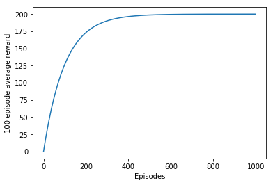

```python
#Define network variables
alpha = 0.0001
beta = 0.0001
H = 4
gamma = 1

def sigmoid(z):
    return 1.0/(1.0+np.exp(-z))

while True:

    #Actor
    a_w_l = np.random.randn(H)

    #Critic
    c_w_l = np.random.randn(H)

    #Initialise state
    state = env.reset()

    #Training initialisation
    running_reward = 0
    reward_sum = 0
    num_eps=0
    t=0
    training_progress = []
    done = True

    for i in range(1000):

        while True:
            if done:
                t=0
                num_eps+=1
                running_reward = 0.99*running_reward + 0.01*reward_sum
                training_progress.append(running_reward)
                reward_sum=0
                state = env.reset()

                #Sample an action a
                a_l = np.dot(a_w_l, state)
                logp = sigmoid(a_l)

                action = 1 if 0.5<logp else 0

                #Q(s,a)
                q = np.dot(c_w_l, state)

            #Observe the reward and transition state s' (observation)
            next_state, reward, done, _ = env.step(action)
            reward_sum += reward
            t+=1

            #Sample an action a'
            a_l = np.dot(a_w_l, next_state)
            next_logp = sigmoid(a_l)

            next_action = 1 if 0.5<next_logp else 0

            #Q(s',a')
            next_q = np.dot(c_w_l, next_state)


            #Parameter updates
            td_error = reward + gamma*next_q - q

            pg = (1-logp)*q

            #Backpropagate
            #Actor
            a_d_w_l = np.dot(state.T,pg)
            a_w_l += alpha*a_d_w_l

            #Critic
            c_d_w_l = np.dot(state.T,td_error)

            c_w_l -= beta*c_d_w_l

            state = next_state
            action = next_action
            q=next_q
            logp = next_logp

            if done:

                break

    if running_reward>195:
#         print (a_w_l)
        break

plt.plot(training_progress)
plt.ylabel('100 episode average reward')
plt.xlabel('Episodes')
plt.show()
```